# MITB Capstone Project

When 1 + 1 > 2: How Modern Data Science Could Complement Actuarial Science in Claim Cost Estimation - Supervised Learning Methods

Jasper Lok (Supervisor: Professor Kam Tin Seong)

25 April, 2021

# 1 Getting Started

## 1.1 Setup the R environment for the analysis later

```r
packages <- c('tidyverse', 'funModeling', 'tidymodels', 'doParallel', 'lubridate', 'usemodels', 'ranger', 'vip', 'pdp', 'iml', 'skimr', 'plotly', 'ggpubr', 'stacks', 'ggExtra', 'ggpointdensity', 'textrecipes', 'rules', 'xrf', 'MASS', 'olsrr', 'rstanarm')

for (p in packages){
  if(!require (p, character.only = T)){
    install.packages(p)
  }
  library(p, character.only = T)
}
```

## 1.2 Call the relevant dataset

First read in the data as the master data and ensure the variables are read in correct data types.

```r
df_base <- read_csv("data/data_eda_actLoss_3.csv") %>%
  dplyr::select(-c(ClaimNumber,
                   num_week_paid_ult)) %>%
  dplyr::select(-starts_with(c("acc", "report"))) %>%
  filter(Gender != "U") %>%
  drop_na() %>%
  sample_frac(0.3)
```

Next, from the master data, create the relevant sets for the model building later.

```r
# Dataset for models with pre-text mining during EDA stage
df <- df_base %>%
  dplyr::select(-c(ClaimDescription, UltimateIncurredClaimCost, InitialIncurredClaimCost))
```

```r
# Dataset for building sub models based on the number of week paid initial estimated
df_less20wk <- df_base %>%
  filter(num_week_paid_init < 20) %>%
  dplyr::select(-c(ClaimDescription, UltimateIncurredClaimCost, InitialIncurredClaimCost))

df_more20wk <- df_base %>%
  filter(num_week_paid_init >= 20) %>%
  dplyr::select(-c(ClaimDescription, UltimateIncurredClaimCost, InitialIncurredClaimCost))
```

```r
# Dataset for direct modeling on text fields
df_wClmDesc <- df_base %>%
  dplyr::select(-c(UltimateIncurredClaimCost, InitialIncurredClaimCost)) %>%
  dplyr::select(-starts_with("injury_"))
```

```r
# Dataset for predicting on the ultimate claim cost directly
df_ult <- df_base %>%
  dplyr::select(-c(init_ult_diff, ClaimDescription))
```

Also, to compare the model results if outliers are not removed

```r
df_org <- read_csv("data/actuarial_loss_train.csv") %>%
  dplyr::select(-c(ClaimNumber)) %>%
  filter(Gender != "U") %>%
  drop_na()
```

## 1.3 Define the relevant parameters for the analysis

```r
# Define the random seeds for reproducibility
set.seed(123)

# Proportion between training and testing dataset
prop_train_test <- 0.6

# Define the model performance metrics we would like to output later
model_metrics <- metric_set(rmse, rsq, mase)

# Number of grid for k-fold validation
num_grid <- 5

# Set the parameters on how many variables to extract for variable importance
vip_var_num <- 10

# List of models will be fitted in this analysis
model_list <- c("ranger", "earth", "glmnet", "xgboost", "kknn")

# List of models to extract out the variable importance
# Note that kknn doesn't have variable importance, hence its being removed from the list
vip_model_list <- model_list %>%
  purrr::discard(.p = ~stringr::str_detect(.x, "kknn"))
```

## 1.4 Register the number of cores for parallel computing

```r
registerDoParallel() #as many physical cores as available.
```

## 1.5 Data splitting

To compare the accuracy across different models, the dataset is split into training and testing dataset. Training dataset will be used to train the models and the models will be used to perform prediction on the testing dataset.

Cross validation will be performed to ensure the models are not overfitted.

First, I will perform pre-processing on the dataset before splitting the data.

```r
# Dataset with pre-text mining during EDA stage
df_split <- initial_split(df,
                            prop = prop_train_test,
                            strata = init_ult_diff)

df_train <- training(df_split)
df_test <- testing(df_split)

df_folds <- vfold_cv(df_train, strata = init_ult_diff)
df_folds
```

```
## #  10-fold cross-validation using stratification
## # A tibble: 10 x 2
##    splits             id
##    <list>             <chr>
##  1 <split [7.5K/840]> Fold01
##  2 <split [7.5K/840]> Fold02
##  3 <split [7.5K/837]> Fold03
##  4 <split [7.5K/836]> Fold04
##  5 <split [7.5K/836]> Fold05
##  6 <split [7.5K/836]> Fold06
##  7 <split [7.5K/836]> Fold07
##  8 <split [7.5K/836]> Fold08
##  9 <split [7.5K/836]> Fold09
## 10 <split [7.5K/836]> Fold10
```

Then, I will define the general recipe for the different machine learning models.

```r
gen_recipe <- recipe(init_ult_diff ~ ., data = df_train) %>%
  step_date(c(DateTimeOfAccident, DateReported)) %>%
  step_mutate(DateTimeOfAccident_hr = lubridate::hour(DateTimeOfAccident),
              DateTimeOfAccident_hr = factor(DateTimeOfAccident_hr, order = TRUE),
              DateTimeOfAccident_year = factor(DateTimeOfAccident_year, order = TRUE),
              DateReported_year = factor(DateReported_year, order = TRUE)) %>%
  update_role(c(DateTimeOfAccident, DateReported), new_role = "id") %>% # update the roles of original date variables to "id"
  prep()

# Apply the pre-processing on new dataset
df_less20wk <- bake(gen_recipe, new_data = NULL)
df_more20wk <- bake(gen_recipe, new_data = NULL)
```

**Summary** function is used to check the data type to ensure they are in the correct data type before building machine learning models.

```r
gen_recipe %>% summary()
```

```
## # A tibble: 26 x 4
##    variable           type    role      source
##    <chr>              <chr>   <chr>     <chr>
##  1 DateTimeOfAccident date    id        original
##  2 DateReported       date    id        original
##  3 Age                numeric predictor original
##  4 Gender             nominal predictor original
##  5 MaritalStatus      nominal predictor original
##  6 DependentChildren  numeric predictor original
##  7 DependentsOther    numeric predictor original
##  8 WeeklyWages        numeric predictor original
##  9 PartTimeFullTime   nominal predictor original
## 10 HoursWorkedPerWeek numeric predictor original
## # ... with 16 more rows
```

Perform the necessary data splitting & cross validation for the remaining of the dataset.

```r
# Dataset for sub models building
# Less than 20 weeks paid initially estimated
df_less20wk_split <- initial_split(df_less20wk,
                            prop = prop_train_test,
                            strata = init_ult_diff)

df_less20wk_train <- training(df_less20wk_split)
df_less20wk_test <- testing(df_less20wk_split)

df_less20wk_folds <- vfold_cv(df_less20wk_train,
                              strata = init_ult_diff)

df_less20wk_folds
```

```
## #  10-fold cross-validation using stratification
## # A tibble: 10 x 2
##    splits             id
##    <list>             <chr>
##  1 <split [4.5K/504]> Fold01
##  2 <split [4.5K/504]> Fold02
##  3 <split [4.5K/504]> Fold03
##  4 <split [4.5K/504]> Fold04
##  5 <split [4.5K/504]> Fold05
##  6 <split [4.5K/504]> Fold06
##  7 <split [4.5K/500]> Fold07
##  8 <split [4.5K/500]> Fold08
##  9 <split [4.5K/500]> Fold09
## 10 <split [4.5K/500]> Fold10
```

```r
# More than 20 weeks paid initially estimated
df_more20wk_split <- initial_split(df_more20wk,
                            prop = prop_train_test,
                            strata = init_ult_diff)

df_more20wk_train <- training(df_more20wk_split)
df_more20wk_test <- testing(df_more20wk_split)

df_more20wk_folds <- vfold_cv(df_more20wk_train,
                              strata = init_ult_diff)

df_more20wk_folds
```

```
## #  10-fold cross-validation using stratification
## # A tibble: 10 x 2
##    splits             id
##    <list>             <chr>
##  1 <split [4.5K/504]> Fold01
##  2 <split [4.5K/504]> Fold02
##  3 <split [4.5K/504]> Fold03
##  4 <split [4.5K/504]> Fold04
##  5 <split [4.5K/504]> Fold05
##  6 <split [4.5K/504]> Fold06
##  7 <split [4.5K/500]> Fold07
##  8 <split [4.5K/500]> Fold08
##  9 <split [4.5K/500]> Fold09
## 10 <split [4.5K/500]> Fold10
```

```r
# Dataset with claim descriptions
df_wClmDesc_split <- initial_split(df_wClmDesc,
                            prop = prop_train_test,
                            strata = init_ult_diff)

df_wClmDesc_train <- training(df_wClmDesc_split)
df_wClmDesc_test <- testing(df_wClmDesc_split)

df_wClmDesc_folds <- vfold_cv(df_wClmDesc_train, strata = init_ult_diff)
df_wClmDesc_folds
```

```
## #  10-fold cross-validation using stratification
## # A tibble: 10 x 2
##    splits             id
##    <list>             <chr>
##  1 <split [7.5K/840]> Fold01
##  2 <split [7.5K/840]> Fold02
##  3 <split [7.5K/837]> Fold03
##  4 <split [7.5K/836]> Fold04
##  5 <split [7.5K/836]> Fold05
##  6 <split [7.5K/836]> Fold06
##  7 <split [7.5K/836]> Fold07
##  8 <split [7.5K/836]> Fold08
##  9 <split [7.5K/836]> Fold09
## 10 <split [7.5K/836]> Fold10
```

```r
# Dataset with ultimate claim amount
df_ult_split <- initial_split(df_ult,
                            prop = prop_train_test,
                            strata = UltimateIncurredClaimCost)

df_ult_train <- training(df_ult_split)
df_ult_test <- testing(df_ult_split)

df_ult_folds <- vfold_cv(df_ult_train, strata = UltimateIncurredClaimCost)
df_ult_folds
```

```
## #  10-fold cross-validation using stratification
## # A tibble: 10 x 2
##    splits             id
##    <list>             <chr>
##  1 <split [7.5K/840]> Fold01
##  2 <split [7.5K/840]> Fold02
##  3 <split [7.5K/837]> Fold03
##  4 <split [7.5K/836]> Fold04
##  5 <split [7.5K/836]> Fold05
##  6 <split [7.5K/836]> Fold06
##  7 <split [7.5K/836]> Fold07
##  8 <split [7.5K/836]> Fold08
##  9 <split [7.5K/836]> Fold09
## 10 <split [7.5K/836]> Fold10
```

```r
# Orginal Dataset
df_org_split <- initial_split(df_org,
                            prop = prop_train_test,
                            strata = UltimateIncurredClaimCost)

df_org_train <- training(df_org_split)
df_org_test <- testing(df_org_split)

df_org_folds <- vfold_cv(df_org_train, strata = UltimateIncurredClaimCost)
df_org_folds
```

```
## #  10-fold cross-validation using stratification
## # A tibble: 10 x 2
##    splits               id
##    <list>               <chr>
##  1 <split [29.1K/3.2K]> Fold01
##  2 <split [29.1K/3.2K]> Fold02
##  3 <split [29.1K/3.2K]> Fold03
##  4 <split [29.1K/3.2K]> Fold04
##  5 <split [29.1K/3.2K]> Fold05
##  6 <split [29.1K/3.2K]> Fold06
##  7 <split [29.1K/3.2K]> Fold07
##  8 <split [29.1K/3.2K]> Fold08
##  9 <split [29.1K/3.2K]> Fold09
## 10 <split [29.1K/3.2K]> Fold10
```

# 2 Model Building

Here we will start building our models. The unified functions make it easy for the users to use various models for machine learning.

The unified functions also allows us to reuse the same functions for different models.

Note that **step_date** function doesn’t seem to support extraction of time (eg. hour, minutes) according to their online documentation. Therefore, I will further use **step_mutate** function to extract other information. **step_mutate** function allows us to tap on the **mutate** function in **dplyr** package to perform necessary analysis.

## 2.1 Without claim descriptions

### 2.1.1 Random Forest

Here, I will be using different **Tidymodels** packages in building machine learning models. Note the I have leveraged on **user_model** package to generate the templates for model building. The advantages of using such package is the package can generate the model building & tuning templates for commonly used models. The generated template also includes the recommended data pre-processing steps, which makes it easier for the users.

**Step 1:** we will define the “recipe”, which I will specify the dependent variable and training dataset.

```r
# Step 1
ranger_recipe <- gen_recipe
```

**Step 2:** I will indicate some of the model info, such as which R package I am using to build the random forest, what type of model I am building over here (i.e. regression or classification), parameters to be tuned and so on.

```r
# Step 2
ranger_spec <-
  rand_forest(mtry = tune(), min_n = tune(), trees = 50) %>%
  set_mode("regression") %>%
  set_engine("ranger", importance = "impurity")
```

**Step 3:** In this step, I have “chained” the different parts of the machine learning models together as a workflow. The purpose of doing so is to allow us to reuse the same recipe and model specs later in the analysis.

```r
# Step 3
ranger_workflow <-
  workflow() %>%
  add_recipe(ranger_recipe) %>%
  add_model(ranger_spec)
```

**Step 4:** Then, we perform model tuning on the cross validation dataset we created earlier.

```r
# Step 4
set.seed(51107)
ranger_tune <-
  tune_grid(ranger_workflow,
            resamples = df_folds,
            grid = num_grid)
```

```
## i Creating pre-processing data to finalize unknown parameter: mtry
```

**Step 5:**: Once the parameters are tuned, the best model paramters is selected by using **select_best** function as shown below. I have also finalised the workflow so that I can perform predictions on testing data through **last_fit** function.

```r
# Step 5
ranger_final_wf <- ranger_workflow %>%
  finalize_workflow(select_best(ranger_tune))
ranger_fit <- ranger_final_wf %>%
  last_fit(df_split)
```

**Step 6:** To facilitate the model comparison later on, I have collected the predictions and calculated the different model performance metrics.

```r
# Step 6
ranger_pred <- ranger_fit %>%
  collect_predictions()

ranger_metric <- model_metrics(ranger_pred,
                               truth = init_ult_diff,
                               estimate = .pred) %>%
  mutate(model = "ranger") %>%
  pivot_wider(names_from = .metric,
              values_from = .estimate)
```

Next, I will be following the same steps as per what I have described under random forest to build different machine learning models (eg. XGBoost, neural network etc) for model comparison.

### 2.1.2 Multivariate Adaptive Regression Splines (MARS)

As **tidymodels** allows us to modularise the different model components, we can effectively reuse the different model components.

Note that the interface for different model components look broadly the same, flattening the learning curve for the users to use the various models in performing machine learning tasks.

```r
earth_recipe <- gen_recipe %>%
  step_novel(all_nominal(), -all_outcomes()) %>%
  step_dummy(all_nominal(), -all_outcomes()) %>%
  step_zv(all_predictors())

earth_spec <-
  mars(num_terms = tune(), prod_degree = tune(), prune_method = "none") %>%
  set_mode("regression") %>%
  set_engine("earth")

earth_workflow <-
  workflow() %>%
  add_recipe(earth_recipe) %>%
  add_model(earth_spec)

earth_grid <- tidyr::crossing(num_terms = 2 * (1:6), prod_degree = 1:2)

earth_tune <-
  tune_grid(earth_workflow, resamples = df_folds, grid = earth_grid)

earth_fit <- earth_workflow %>%
  finalize_workflow(select_best(earth_tune)) %>%
  last_fit(df_split)
earth_pred <- earth_fit %>%
  collect_predictions()

earth_metric <- model_metrics(earth_pred,
                               truth = init_ult_diff,
                               estimate = .pred) %>%
  mutate(model = "earth") %>%
  pivot_wider(names_from = .metric,
              values_from = .estimate)
```

### 2.1.3 Generalised Linear Model (GLM)

I have also fitted a GLM model below.

```r
glmnet_recipe <- gen_recipe %>%
  step_dummy(all_nominal())

glmnet_spec <-
  linear_reg(penalty = tune(), mixture = tune()) %>%
  set_mode("regression") %>%
  set_engine("glmnet")

glmnet_workflow <-
  workflow() %>%
  add_recipe(glmnet_recipe) %>%
  add_model(glmnet_spec)

glmnet_grid <- tidyr::crossing(penalty = 10^seq(-6, -1, length.out = 20), mixture = c(0.05,
    0.2, 0.4, 0.6, 0.8, 1))

glmnet_tune <-
  tune_grid(glmnet_workflow, resamples = df_folds, grid = glmnet_grid)

glmnet_fit <- glmnet_workflow %>%
  finalize_workflow(select_best(glmnet_tune, "rmse")) %>%
  last_fit(df_split)

glmnet_pred <- glmnet_fit %>%
  collect_predictions()

glmnet_metric <- model_metrics(glmnet_pred,
                               truth = init_ult_diff,
                               estimate = .pred) %>%
  mutate(model = "glmnet") %>%
  pivot_wider(names_from = .metric,
              values_from = .estimate)
```

### 2.1.4 Linear regression

To contrast the GLM (with Gaussian as link function) results above, I have also fitted a multiple regression model.

```r
#lm_recipe <- recipe(formula = init_ult_diff ~ ., data = df_train)

lm_spec <- linear_reg() %>%
  set_mode("regression") %>%
  set_engine("lm")

lm_fit <- fit(lm_spec, init_ult_diff ~ ., df_train)

lm_pred <- predict(lm_fit, df_test) %>%
  bind_cols(df_test %>% dplyr::select(init_ult_diff))

lm_metric <- model_metrics(lm_pred,
                           truth = init_ult_diff,
                           estimate = .pred) %>%
  mutate(model = "lm") %>%
  pivot_wider(names_from = .metric,
              values_from = .estimate)
```

### 2.1.5 XGBoost

```r
# the model tuning for xgboost takes about 5 hours
# to shorten the run time to generate the HTML file, I have indicated the parameters that would give the best model performance based on my previous full run
# to perform the model tuning,

xgboost_recipe <- gen_recipe %>%
  step_dummy(all_nominal())

xgboost_spec <-
#  boost_tree(trees = tune(), min_n = tune(), tree_depth = tune(), learn_rate = tune(),
#    loss_reduction = tune(), sample_size = tune()) %>% # remove '#' for the parameters to be tuned
  boost_tree(trees = 1688, min_n = 38, tree_depth = 11, learn_rate = 0.0778, loss_reduction = 0.00000997,
             sample_size = 0.463) %>% # include '#' in front of the code to skip this code if we want to tune the parameters
  set_mode("regression") %>%
  set_engine("xgboost")

xgboost_workflow <-
  workflow() %>%
  add_recipe(xgboost_recipe) %>%
  add_model(xgboost_spec)

set.seed(12071)
# remove the '#' if we want to tune the parameters
#xgboost_tune <-
#  tune_grid(xgboost_workflow,
#            resamples = df_folds,
#            grid = num_grid)

xgboost_fit <- xgboost_workflow %>%
# remove the '#' if we want to use the current tuned parameters to fit the model
#  finalize_workflow(select_best(xgboost_tune, "rmse")) %>%
  last_fit(df_split)

xgboost_pred <- xgboost_fit %>%
  collect_predictions()

xgboost_metric <- model_metrics(xgboost_pred,
                               truth = init_ult_diff,
                               estimate = .pred) %>%
  mutate(model = "xgboost") %>%
  pivot_wider(names_from = .metric,
              values_from = .estimate)
```

### 2.1.6 K Nearest Neighbours

```r
kknn_spec <-
  nearest_neighbor(neighbors = tune(), weight_func = tune()) %>%
  set_mode("regression") %>%
  set_engine("kknn")

kknn_workflow <-
  workflow() %>%
  add_recipe(gen_recipe) %>%
  add_model(kknn_spec)

set.seed(96032)
kknn_tune <-
  tune_grid(kknn_workflow, resamples = df_folds, grid = num_grid)

kknn_fit <- kknn_workflow %>%
  finalize_workflow(select_best(kknn_tune, "rmse")) %>%
  last_fit(df_split)

kknn_pred <- kknn_fit %>%
  collect_predictions()

kknn_metric <- model_metrics(kknn_pred,
                               truth = init_ult_diff,
                               estimate = .pred) %>%
  mutate(model = "kknn") %>%
  pivot_wider(names_from = .metric,
              values_from = .estimate)
```

## 2.2 With claim descriptions

To facilitate the model comparison, I will be building a random forest machine learning model with directly modeling on the claim descriptions, instead of performing text mining during EDA stage.

Note that we have decided the engine the model specs in the random forest section above. Hence instead of redefine again, I will be using the same specs again. This illustrates the beauty of **tidymodels** interface, allowing the users to reuse some of the machine learning “parts”.

```r
ranger_recipe_clmdesc <-
  recipe(formula = init_ult_diff ~ ., data = df_wClmDesc_train) %>%
  update_role(c(DateTimeOfAccident, DateReported), new_role = "id") %>%
  step_tokenize(ClaimDescription) %>%
  step_stopwords(ClaimDescription) %>%
  step_tokenfilter(ClaimDescription, max_tokens = 20) %>%
  step_tfidf(ClaimDescription)

ranger_workflow_clmdesc <-
  workflow() %>%
  add_recipe(ranger_recipe_clmdesc) %>%
  add_model(ranger_spec)

set.seed(51107)
ranger_tune_clmdesc <-
  tune_grid(ranger_workflow_clmdesc,
            resamples = df_wClmDesc_folds,
            grid = num_grid)
```

```
## i Creating pre-processing data to finalize unknown parameter: mtry
```

```r
ranger_final_wf_clmdesc <- ranger_workflow_clmdesc %>%
  finalize_workflow(select_best(ranger_tune_clmdesc))
ranger_fit_clmdesc <- ranger_final_wf_clmdesc %>%
  last_fit(df_wClmDesc_split)

ranger_clmdesc_pred <- ranger_fit_clmdesc %>%
  collect_predictions()

ranger_clmdesc_metric <- model_metrics(ranger_clmdesc_pred,
                               truth = init_ult_diff,
                               estimate = .pred) %>%
  mutate(model = "ranger_clmdesc") %>%
  pivot_wider(names_from = .metric,
              values_from = .estimate)
```

## 2.3 Model direct on the ultimate claim amount

Similarly, to compare the difference in accuracy between the model fitted on the difference in initial and ultimate claim amount & the model directly fitted on ultimate claim amount, I will fit a random forest model for comparison.

```r
ranger_recipe_ult <-
  recipe(formula = UltimateIncurredClaimCost ~ ., data = df_ult_train) %>%
  step_date(c(DateTimeOfAccident, DateReported)) %>%
  step_mutate(DateTimeOfAccident_hr = lubridate::hour(DateTimeOfAccident),
              DateTimeOfAccident_hr = factor(DateTimeOfAccident_hr, order = TRUE)) %>%
  update_role(c(DateTimeOfAccident, DateReported, InitialIncurredClaimCost), new_role = "id") %>%
  prep()

ranger_workflow_ult <-
  workflow() %>%
  add_recipe(ranger_recipe_ult) %>%
  add_model(ranger_spec)

set.seed(51107)
ranger_tune_ult <-
  tune_grid(ranger_workflow_ult,
            resamples = df_ult_folds,
            grid = num_grid)
```

```
## i Creating pre-processing data to finalize unknown parameter: mtry
```

```r
ranger_fit_ult <- ranger_workflow_ult %>%
  finalize_workflow(select_best(ranger_tune_ult)) %>%
  last_fit(df_ult_split)
ranger_ult_pred <- ranger_fit_ult %>%
  collect_predictions() %>%
  bind_cols(df_ult_test$InitialIncurredClaimCost) %>%
  rename("InitialIncurredClaimCost" = "...6") %>%
  mutate(pred_diff = .pred - InitialIncurredClaimCost,
         act_diff = UltimateIncurredClaimCost - InitialIncurredClaimCost)
```

```
## * NA -> ...6
```

```r
ranger_ult_metric <- model_metrics(ranger_ult_pred,
                               truth = act_diff,
                               estimate = pred_diff) %>%
  mutate(model = "ranger_ult") %>%
  pivot_wider(names_from = .metric,
              values_from = .estimate)
```

## 2.4 Sub models

Sub Model - Less 20 weeks paid initial estimated

```r
ranger_recipe_less20wk <-
  recipe(formula = init_ult_diff ~ ., data = df_less20wk_train)

ranger_workflow_less20wk <-
  workflow() %>%
  add_recipe(ranger_recipe_less20wk) %>%
  add_model(ranger_spec)

set.seed(51107)
ranger_tune_less20wk <-
  tune_grid(ranger_workflow_less20wk,
            resamples = df_less20wk_folds,
            grid = num_grid)
```

```
## i Creating pre-processing data to finalize unknown parameter: mtry
```

```r
ranger_fit_less20wk <- ranger_workflow_less20wk %>%
  finalize_workflow(select_best(ranger_tune_less20wk)) %>%
  last_fit(df_less20wk_split)
```

Sub Model - More 20 weeks paid initial estimated

```r
ranger_recipe_more20wk <-
  recipe(formula = init_ult_diff ~ ., data = df_more20wk_train)

ranger_workflow_more20wk <-
  workflow() %>%
  add_recipe(ranger_recipe_more20wk) %>%
  add_model(ranger_spec)

set.seed(51107)
ranger_tune_more20wk <-
  tune_grid(ranger_workflow_more20wk,
            resamples = df_more20wk_folds,
            grid = num_grid)
```

```
## i Creating pre-processing data to finalize unknown parameter: mtry
```

```r
ranger_fit_more20wk <- ranger_workflow_more20wk %>%
  finalize_workflow(select_best(ranger_tune_more20wk)) %>%
  last_fit(df_more20wk_split)
```

Combine the predictions

```r
ranger_20wk_pred <- bind_rows(ranger_fit_less20wk %>% collect_predictions(),
                         ranger_fit_more20wk %>% collect_predictions())

ranger_20wk_metric <- model_metrics(ranger_20wk_pred,
                                    truth = init_ult_diff,
                                    estimate = .pred)  %>%
  mutate(model = "ranger_20wk") %>%
  pivot_wider(names_from = .metric,
              values_from = .estimate)
```

## 2.5 Variable Selection

In this sub-section, variation selection algorithm is first used to select the variables that are useful in explaining the results.

Then I fit a random forest model by using the subset of the variables.

I have selected top 10 variables based on their variable importance.

```r
ranger_workflow_vip <-
  ranger_workflow %>%
  update_formula(init_ult_diff ~  num_week_paid_init +
                                           WeeklyWages +
                                           injury_body +
                                           Age +
                                           DateReported_year +
                                           DateTimeOfAccident_year +
                                           day_diff +
                                           injury_cause +
                                           injury_type +
                                           HoursWorkedPerWeek)
```

Note that I have reused the workflow object created for random forest and perform an update on the formula.

Somehow the algorithm doesn’t work when I specify I would like to fit a model with a pre-processed variable. So, to overcome this, I apply the bake function on the original dataset and re-split the data point.

```r
df_vip <- bake(gen_recipe, new_data = df)

# Dataset with pre-text mining during EDA stage
df_vip_split <- initial_split(df_vip,
                            prop = prop_train_test,
                            strata = init_ult_diff)

df_vip_train <- training(df_vip_split)
df_vip_test <- testing(df_vip_split)

df_vip_folds <- vfold_cv(df_vip_train, strata = init_ult_diff)
df_vip_folds
```

```
## #  10-fold cross-validation using stratification
## # A tibble: 10 x 2
##    splits             id
##    <list>             <chr>
##  1 <split [7.5K/840]> Fold01
##  2 <split [7.5K/840]> Fold02
##  3 <split [7.5K/837]> Fold03
##  4 <split [7.5K/836]> Fold04
##  5 <split [7.5K/836]> Fold05
##  6 <split [7.5K/836]> Fold06
##  7 <split [7.5K/836]> Fold07
##  8 <split [7.5K/836]> Fold08
##  9 <split [7.5K/836]> Fold09
## 10 <split [7.5K/836]> Fold10
```

Once the dataset is prepared, I will start performing tuning to build the machine learning models.

```r
set.seed(51107)
ranger_tune_vip <-
  tune_grid(ranger_workflow_vip,
            resamples = df_vip_folds,
            grid = num_grid)
```

```
## i Creating pre-processing data to finalize unknown parameter: mtry
```

```r
ranger_fit_vip <- ranger_workflow_vip %>%
  finalize_workflow(select_best(ranger_tune_vip)) %>%
  last_fit(df_vip_split)
ranger_vip_pred <- ranger_fit_vip %>%
  collect_predictions()

ranger_vip_metric <- model_metrics(ranger_vip_pred,
                               truth = init_ult_diff,
                               estimate = .pred) %>%
  mutate(model = "ranger_vip") %>%
  pivot_wider(names_from = .metric,
              values_from = .estimate)
```

## 2.6 Without data pre-processing & EDA

For comparison purpose, I have also fitted the model without performing any forms of EDA to compare the model performance.

```r
ranger_recipe_org <-
  recipe(formula = UltimateIncurredClaimCost ~ ., data = df_org_train) %>%
  update_role(c(DateTimeOfAccident, DateReported, ClaimDescription), new_role = "id") %>% # update the roles of original date variables to "id"
  prep()

ranger_workflow_org <-
  workflow() %>%
  add_recipe(ranger_recipe_org) %>%
  add_model(ranger_spec)

set.seed(51107)
ranger_tune_org <-
  tune_grid(ranger_workflow_org,
            resamples = df_org_folds,
            grid = num_grid)
```

```
## i Creating pre-processing data to finalize unknown parameter: mtry
```

```r
ranger_fit_org <- ranger_workflow_org %>%
  finalize_workflow(select_best(ranger_tune_org)) %>%
  last_fit(df_org_split)
ranger_org_pred <- ranger_fit_org %>%
  collect_predictions() %>%
  bind_cols(df_org_test$InitialIncurredCalimsCost) %>%
  rename("InitialIncurredClaimCost" = "...6") %>%
  mutate(pred_diff = .pred - InitialIncurredClaimCost,
         act_diff = UltimateIncurredClaimCost - InitialIncurredClaimCost)
```

```
## * NA -> ...6
```

```r
ranger_org_metric <- model_metrics(ranger_org_pred,
                               truth = act_diff,
                               estimate = pred_diff) %>%
  mutate(model = "ranger_org") %>%
  pivot_wider(names_from = .metric,
              values_from = .estimate)
```

# 3 Model Performance

## 3.1 Comparison on Metrics

### 3.1.1 Comparison on the different models

```r
tibble() %>%
  bind_rows(ranger_metric) %>%
  bind_rows(xgboost_metric) %>%
  bind_rows(glmnet_metric) %>%
  bind_rows(lm_metric) %>%
  bind_rows(earth_metric) %>%
  bind_rows(kknn_metric)
```

```
## # A tibble: 6 x 5
##   .estimator model    rmse   rsq  mase
##   <chr>      <chr>   <dbl> <dbl> <dbl>
## 1 standard   ranger  1572. 0.436 0.471
## 2 standard   xgboost 1603. 0.426 0.490
## 3 standard   glmnet  1675. 0.357 0.529
## 4 standard   lm      1693. 0.343 0.521
## 5 standard   earth   1708. 0.331 0.538
## 6 standard   kknn    1773. 0.280 0.544
```

Below are the observations:

- In general, the results from the various metrics are consistent with one another.
- Out of all the models, ranger model has the highest accuracy.

### 3.1.2 Comparison on model *with* data cleaning & *without* data cleaning

```r
tibble() %>%
  bind_rows(ranger_org_metric) %>%
  bind_rows(ranger_ult_metric)
```

```
## # A tibble: 2 x 5
##   .estimator model        rmse   rsq  mase
##   <chr>      <chr>       <dbl> <dbl> <dbl>
## 1 standard   ranger_org 23762. 0.303 0.671
## 2 standard   ranger_ult  1775. 0.293 0.509
```

The model performance improved significantly after we perform data cleaning. THis is because there are unreasonable values and outliers within the dataset. Below is one of the example of unreasonable values:

```r
df_org %>%
  dplyr::select(HoursWorkedPerWeek) %>%
  skim()
```

Data summary

| Name | Piped data |
| --- | --- |
| Number of rows | 53969 |
| Number of columns | 1 |
| _______________________ |  |
| Column type frequency: |  |
| numeric | 1 |
| ________________________ |  |
| Group variables | None |

**Variable type: numeric**

| skim_variable | n_missing | complete_rate | mean | sd | p0 | p25 | p50 | p75 | p100 | hist |
| --- | --- | --- | --- | --- | --- | --- | --- | --- | --- | --- |
| HoursWorkedPerWeek | 0 | 1 | 37.73 | 12.57 | 0 | 38 | 38 | 40 | 640 | ▇▁▁▁▁ |

Note that the max hours is 640 hours, but the max hours within a week is 168 hours (ie. 24 hours over 7 days).

### 3.1.3 Comparison on directly model on actual claim cost and claim difference between initial and actual

```r
tibble() %>%
  bind_rows(ranger_ult_metric) %>%
  bind_rows(ranger_metric)
```

```
## # A tibble: 2 x 5
##   .estimator model       rmse   rsq  mase
##   <chr>      <chr>      <dbl> <dbl> <dbl>
## 1 standard   ranger_ult 1775. 0.293 0.509
## 2 standard   ranger     1572. 0.436 0.471
```

Above does not imply we should always model on the claim difference. This is where we could apply our domain knowledge to see which way of analyzing the problems could provide us the highest accuracy.

### 3.1.4 Comparison on full model and simpler model

```r
tibble() %>%
  bind_rows(ranger_metric) %>%
  bind_rows(ranger_vip_metric)
```

```
## # A tibble: 2 x 5
##   .estimator model       rmse   rsq  mase
##   <chr>      <chr>      <dbl> <dbl> <dbl>
## 1 standard   ranger     1572. 0.436 0.471
## 2 standard   ranger_vip 1592. 0.409 0.474
```

Note that the model performance for the simpler model is also same as the full model. This indicates that the simpler model requires less inputs to have similar level of accuracy.

### 3.1.5 Comparison on different text mining method

```r
tibble() %>%
  bind_rows(ranger_metric) %>%
  bind_rows(ranger_clmdesc_metric)
```

```
## # A tibble: 2 x 5
##   .estimator model           rmse   rsq  mase
##   <chr>      <chr>          <dbl> <dbl> <dbl>
## 1 standard   ranger         1572. 0.436 0.471
## 2 standard   ranger_clmdesc 1511. 0.459 0.436
```

The metric result under **textrecipe** method is better than the one model by using **tidytext** method. This is probably due to the tf-idf function used under **textrecipe** method.

## 3.2 Variable importance Comparison Across Models

In this section, I will extract the variable importance from various machine learning models and print them out for comparison.

### 3.2.1 Without Claim Descriptions

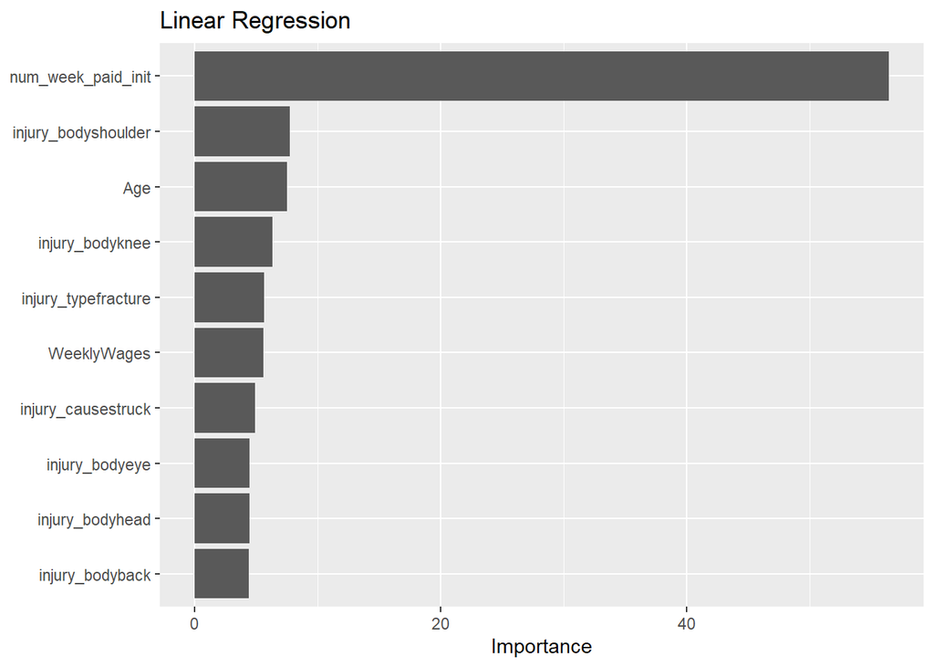

```r
lm_fit %>%
  vi() %>%
  slice_max(abs(Importance), n = vip_var_num) %>%
  ungroup() %>%
  mutate(
    Importance = abs(Importance),
    Variable = fct_reorder(Variable, Importance)) %>%
  ggplot(aes(Importance, Variable)) +
  geom_col(show.legend =  FALSE) +
  labs(y = NULL, title = "Linear Regression")
```

```r
for (i in vip_model_list){

  assign(paste0(i, "_vip"), pull_workflow_fit(get(paste0(i, "_fit"))$.workflow[[1]]) %>% vi())

  assign(paste0(i, "_vip_graph"), get(paste0(i, "_vip")) %>%
  slice_max(abs(Importance), n = vip_var_num) %>%
  ungroup() %>%
  mutate(
    Importance = abs(Importance),
    Variable = fct_reorder(Variable, Importance),
  ) %>%
  ggplot(aes(Importance, Variable)) +
  geom_col(show.legend = FALSE) +
  labs(y = NULL, title = sym(i)))

}
```

Note that knn model doesn’t have vip. Hence it is not included in the list above.

### 3.2.2 With Claim Descriptions

```r
ranger_vip_clmdesc <- pull_workflow_fit(ranger_fit_clmdesc$.workflow[[1]]) %>%
  vi()

ranger_vip_graph_clmdesc <- ranger_vip_clmdesc %>%
  slice_max(abs(Importance), n = vip_var_num) %>%
  ungroup() %>%
  mutate(
    Importance = abs(Importance),
    Variable = fct_reorder(Variable, Importance),
  ) %>%
  ggplot(aes(Importance, Variable)) +
  geom_col(show.legend = FALSE) +
  labs(y = NULL, title = "ranger - Model directly on claim descriptions")
```

### 3.2.3 Model directly on ultimate claim cost

```r
ranger_vip_ult <- pull_workflow_fit(ranger_fit_ult$.workflow[[1]]) %>%
  vi()

ranger_vip_graph_ult <- ranger_vip_ult %>%
  slice_max(abs(Importance), n = vip_var_num) %>%
  ungroup() %>%
  mutate(
    Importance = abs(Importance),
    Variable = fct_reorder(Variable, Importance),
  ) %>%
  ggplot(aes(Importance, Variable)) +
  geom_col(show.legend = FALSE) +
  labs(y = NULL, title = "ranger - Model directly on ultimate claim amount")
```

### 3.2.4 Sub-models

```r
# 20 weeks and below
ranger_vip_less20wk <- pull_workflow_fit(ranger_fit_less20wk$.workflow[[1]]) %>%
  vi()

ranger_vip_graph_less20wk <- ranger_vip_less20wk %>%
  slice_max(abs(Importance), n = vip_var_num) %>%
  ungroup() %>%
  mutate(
    Importance = abs(Importance),
    Variable = fct_reorder(Variable, Importance),
  ) %>%
  ggplot(aes(Importance, Variable)) +
  geom_col(show.legend = FALSE) +
  labs(y = NULL, title = "ranger - submodel with less than 20 weeks initial estimated paid week")

# 20 weeks and above
ranger_vip_more20wk <- pull_workflow_fit(ranger_fit_more20wk$.workflow[[1]]) %>%
  vi()

ranger_vip_graph_more20wk <- ranger_vip_more20wk %>%
  slice_max(abs(Importance), n = vip_var_num) %>%
  ungroup() %>%
  mutate(
    Importance = abs(Importance),
    Variable = fct_reorder(Variable, Importance),
  ) %>%
  ggplot(aes(Importance, Variable)) +
  geom_col(show.legend = FALSE) +
  labs(y = NULL, title = "ranger - submodel with more than 20 weeks initial estimated paid week")
```

### 3.2.5 With variable selection

```r
# Variable selection through variable importance
ranger_vip_vip <- pull_workflow_fit(ranger_fit_vip$.workflow[[1]]) %>%
  vi()

ranger_vip_graph_vip <- ranger_vip_vip %>%
  slice_max(abs(Importance), n = vip_var_num) %>%
  ungroup() %>%
  mutate(
    Importance = abs(Importance),
    Variable = fct_reorder(Variable, Importance),
  ) %>%
  ggplot(aes(Importance, Variable)) +
  geom_col(show.legend = FALSE) +
  labs(y = NULL, title = "Random Forest - Var Select - vip")
```

### 3.2.6 Model directly on ultimate claim cost - original dataset

```r
ranger_vip_org <- pull_workflow_fit(ranger_fit_org$.workflow[[1]]) %>%
  vi()

ranger_vip_graph_org <- ranger_vip_org %>%
  slice_max(abs(Importance), n = vip_var_num) %>%
  ungroup() %>%
  mutate(
    Importance = abs(Importance),
    Variable = fct_reorder(Variable, Importance),
  ) %>%
  ggplot(aes(Importance, Variable)) +
  geom_col(show.legend = FALSE) +
  labs(y = NULL, title = "ranger - Model directly on ultimate claim amount")
```

### 3.2.4 Comparison on Variable Importance

Finally, the variable importance graphs for different machine learning models are printed out for comparison.

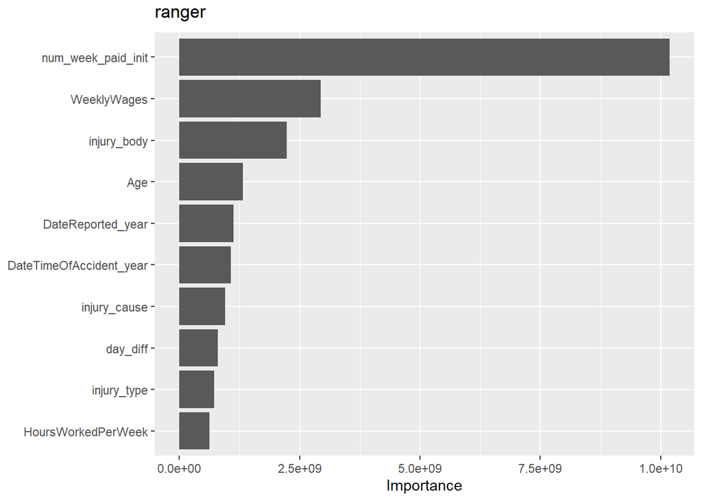

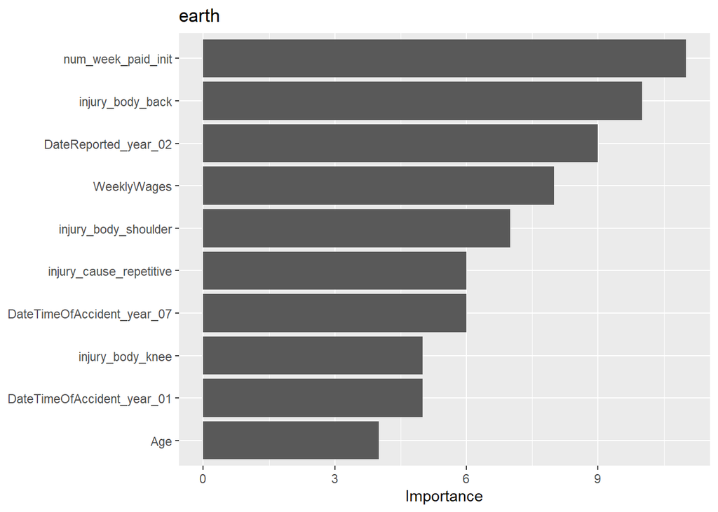

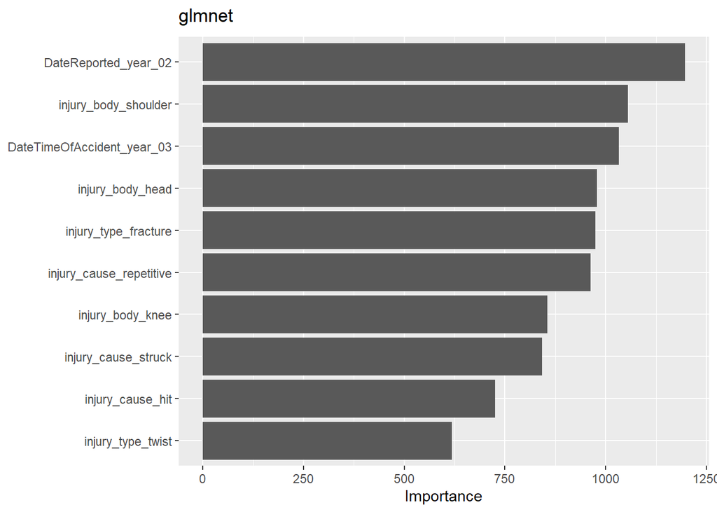

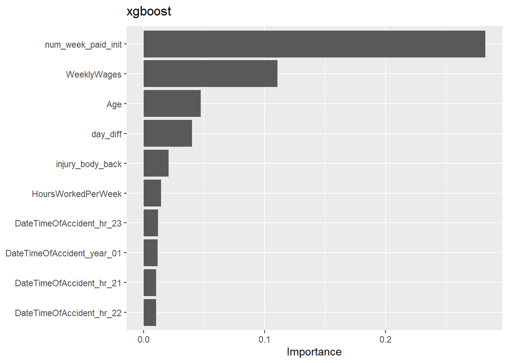

```r
for (i in vip_model_list){
  print(get(paste0(i, "_vip_graph")))
}
```

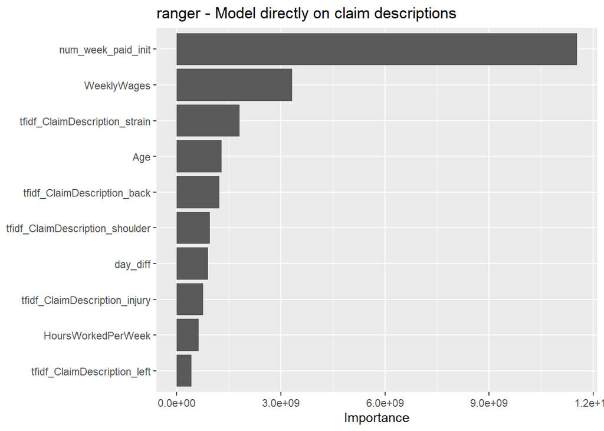

```r
ranger_vip_graph_clmdesc
```

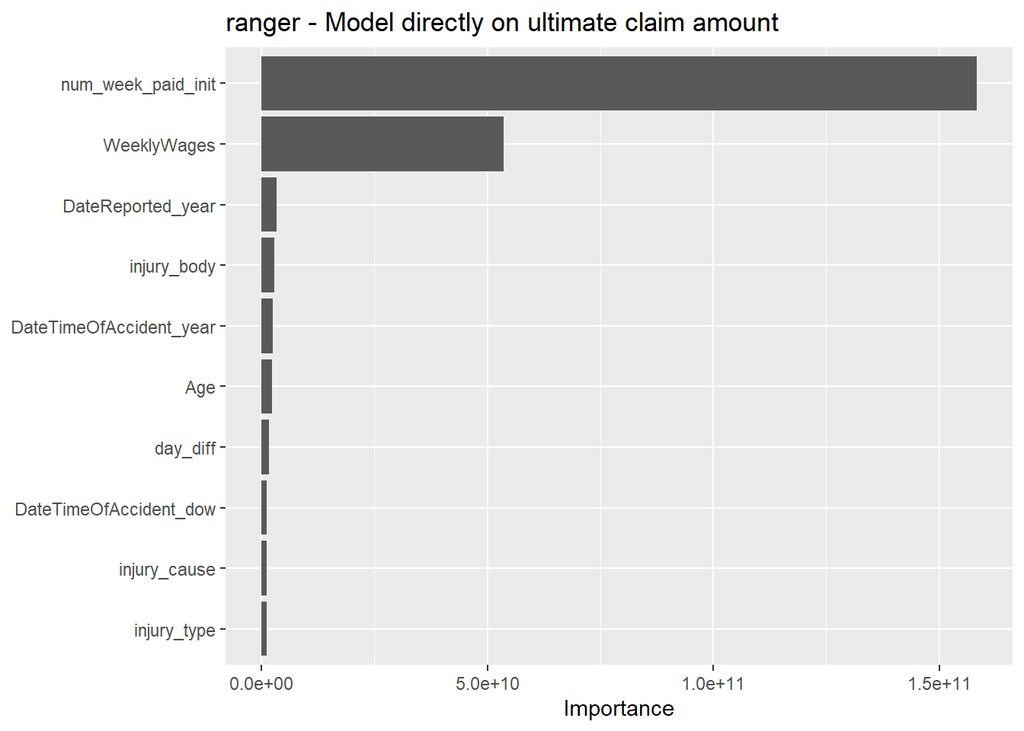

```r
ranger_vip_graph_ult
```

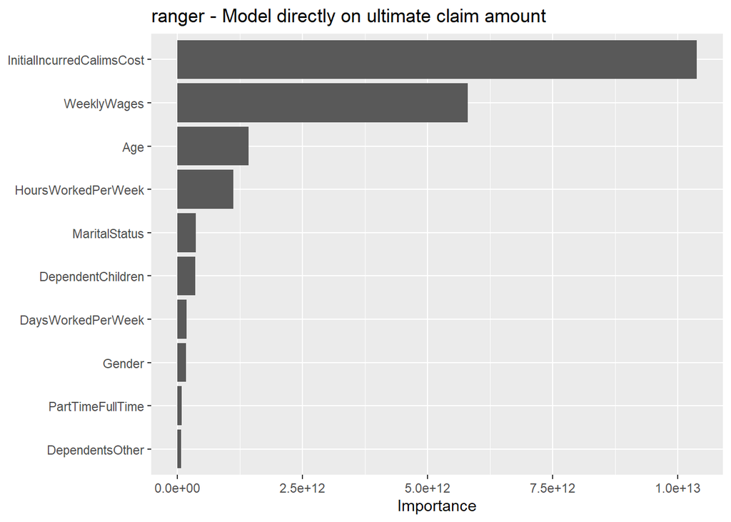

```r
ranger_vip_graph_org
```

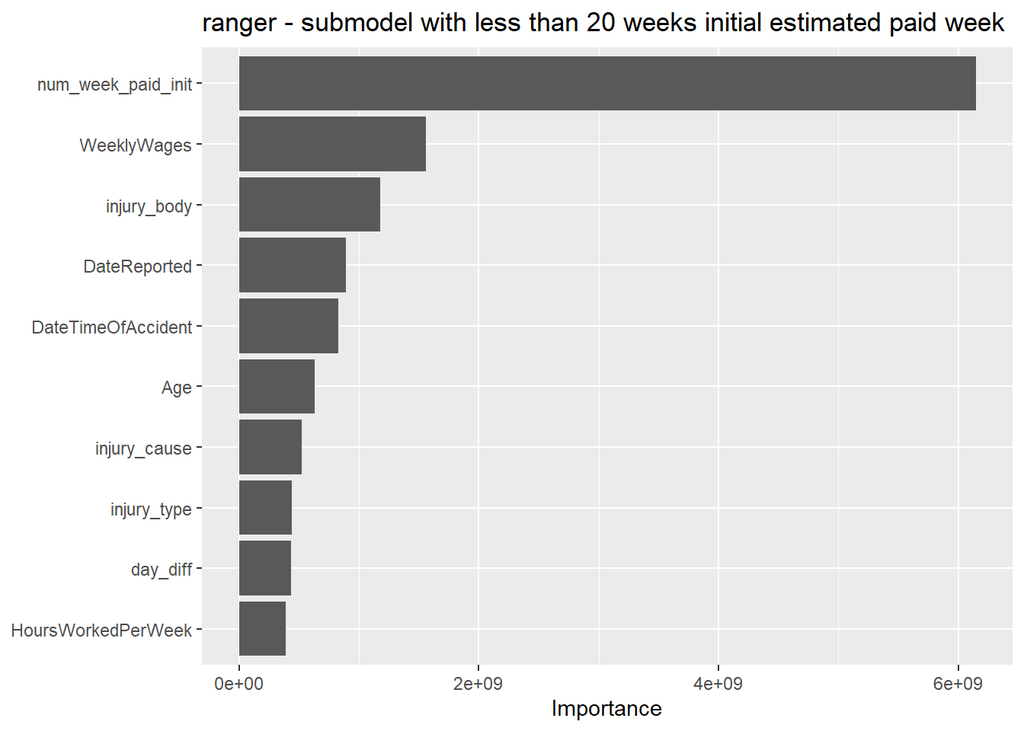

```r
ranger_vip_graph_less20wk
```

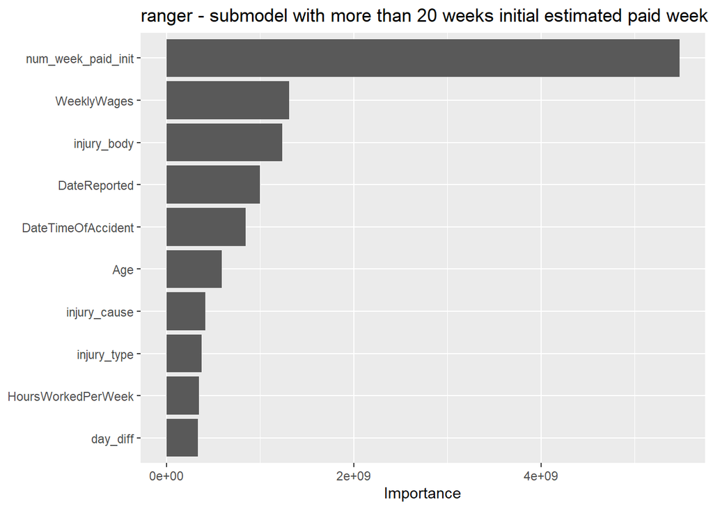

```r
ranger_vip_graph_more20wk
```

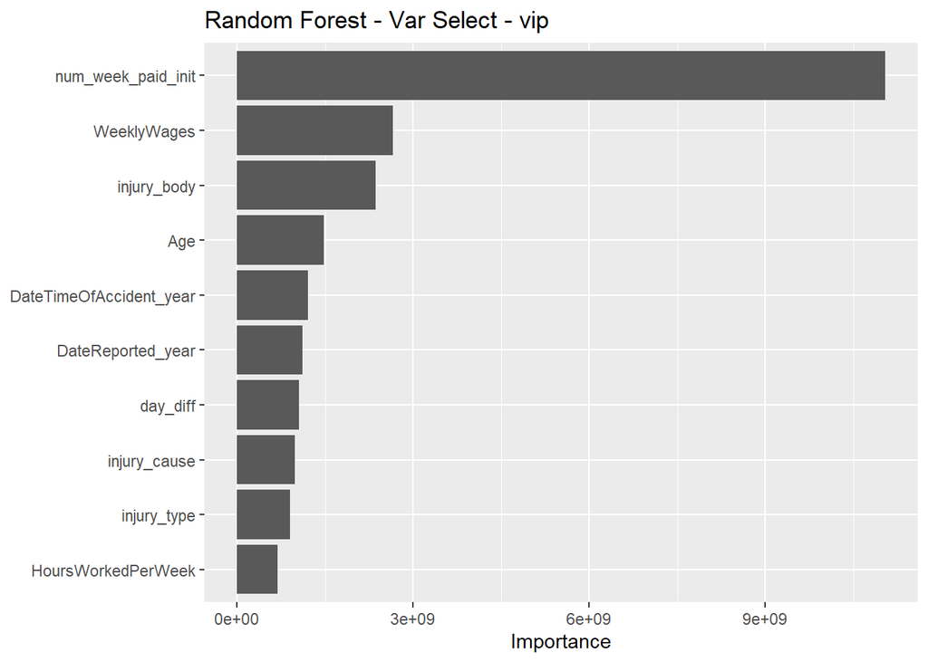

```r
ranger_vip_graph_vip
```

Most of the machine learning models agree that *num_week_paid_init* is the most important variable in explaining the results.

## 3.3 Plot on Predictions vs Actual

Define the attributes for the graphs

```r
graph_alpha <- 0.3
graph_color <- "blue"
graph_line_slope <- 1
graph_line_intercept <- 0
```

Next, I will plot the graphs.

### 3.3.1 Without Claim Descriptions

```r
lm_predVsActual <- lm_pred %>%
  ggplot(aes(init_ult_diff, .pred)) +
  geom_point(alpha = graph_alpha, color = graph_color) +
  geom_abline(slope = graph_line_slope, intercept = graph_line_intercept) +
  xlab("Actual Diff") +
  ylab("Predicted Diff") +
  labs(title = "Linear Model")
```

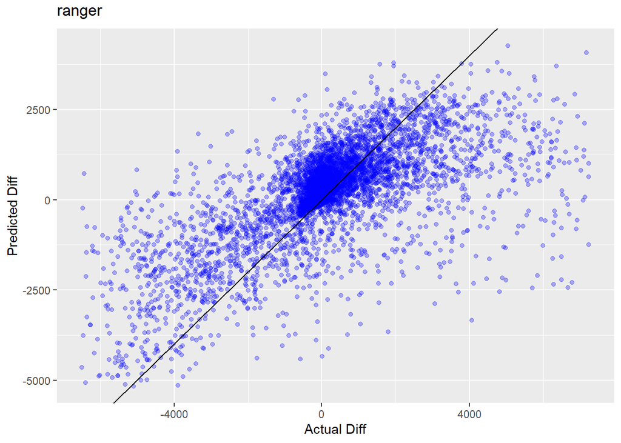

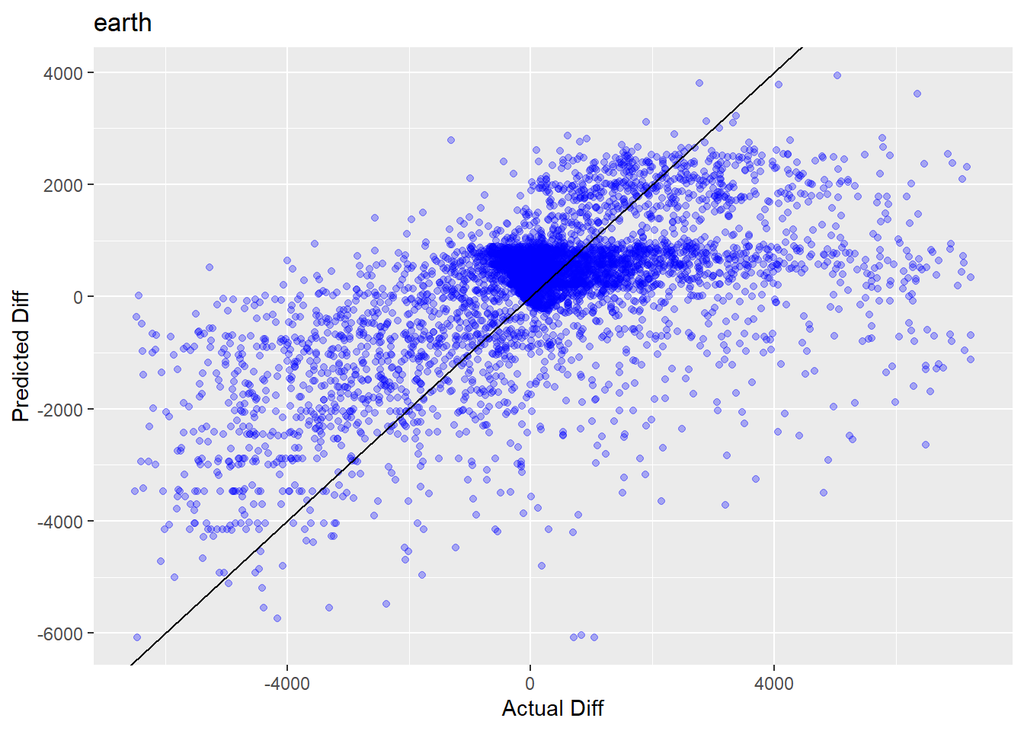

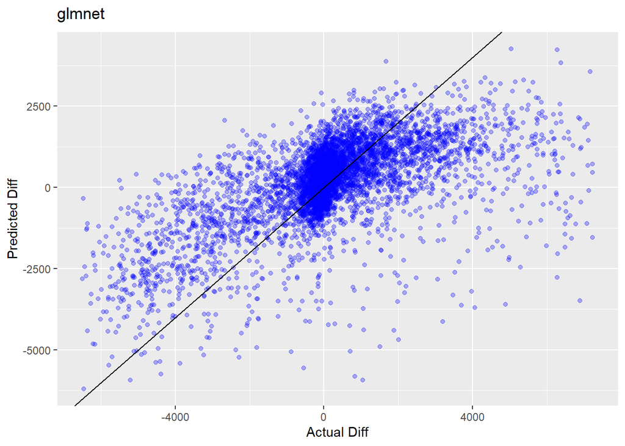

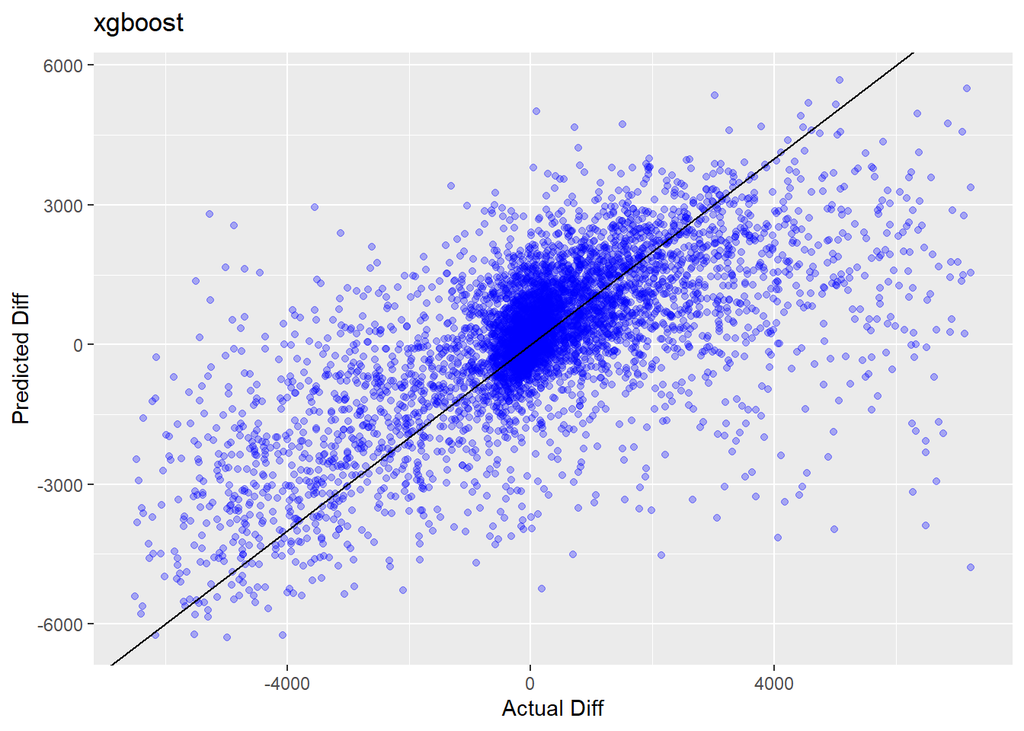

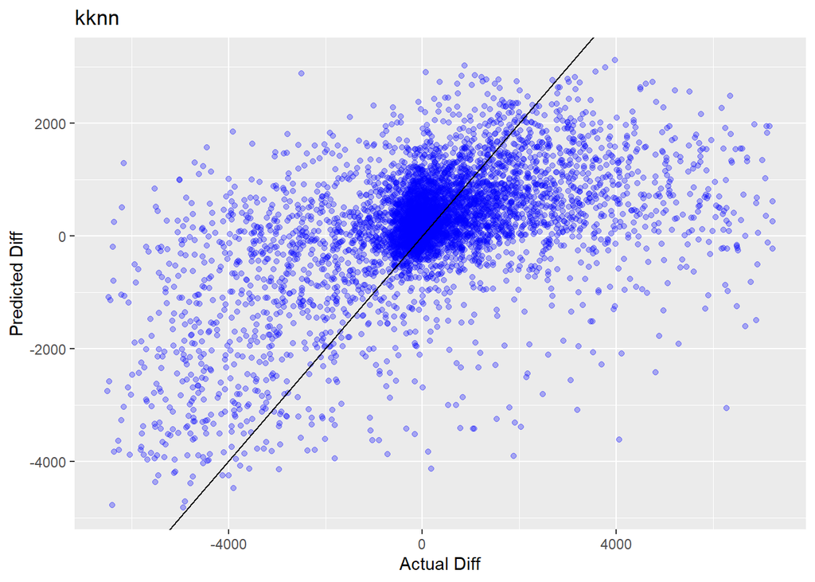

```r
for (i in model_list){
  assign(paste0(i, "_predVsActual"),
         collect_predictions(get(paste0(i, "_fit"))) %>%
          ggplot(aes(init_ult_diff, .pred)) +
          geom_point(alpha = graph_alpha, color = graph_color) +
          geom_abline(slope = graph_line_slope, intercept = graph_line_intercept) +
          xlab("Actual Diff") +
          ylab("Predicted Diff") +
          labs(title = sym(i)))

  print(get(paste0(i, "_predVsActual")))
}
```